# Sistemi masovnog opsluživanja u Juliji

Simulacija redova čekanja ili sistema masovnog opsluživanja (SMO) uključuje procese gde se generišu slučajni događaji. Pojave takvih događaja imaju zakonitost koja odgovara nekoj od raspodela verovatnoće. Ovde se posmatraju rapodele:

- Normalna ili Gausova raspodela,
- Eksponencijalna raspodela i
- Poasonova raspodela.

## Raspodele

Da bi se generisali slučajni podaci i napravila njihova analiza potrebno je uključiti sledeće pakete...

```julia
using Random, Distributions, Plots
Random.seed!(1234);
```

Dodatno, seme generatora slučajnih brojeva je postavljano kako bi vremenska serija generisanih podataka bila ponovljiva.

Za potrebe analize će se koristiti funkcija *hist* čija namena je da napravi histogram, tj. da prebroji broj pojava vrednosti u ekvidistantnim uzastopnim intervalima. (Ovo je ranije viđen kod.)

```julia
function hist(data, nbins)
    min = minimum(data)
    max = maximum(data)

    delta = (max-min)/nbins      # veličina (širina) grupe
    out = zeros(nbins)           # broj elemenata u grupama je inicijalno 0
    bin = zeros(nbins)           # niz vrednosti sredina grupa

    start = min                  # leva granica grupe
    for k = 1:nbins
      stop   = start + delta     # desna granica
      # broj elemenata u grupi
      out[k] = sum((data .>= start) .& (data .< stop))
      bin[k] = start + delta/2.  # vrednost na sredini grupe
      start  = stop              # leva kranica naredne grupe
    end
    return out, bin
end;
```

Za svaku od posmatranih raspodela se koristi funkcija za generisanje niza slučajnih vrednosti *rand* gde je prvi parametar te funkcije tip distribucije.

### Exsponencijalna raspodela

Parametar exsponencijalne raspodele je parametar brzine ili učestalost pojava u jedinici vremena.

```julia
λ = 0.2         # λ - učestalost pojava u jed. vremena
θ = 1 / λ       # θ - srednje vreme pojava

distribucija = Exponential(θ)
f = rand(distribucija, 10^6)    # generisanje niza od milion vrednosti
@show( mean(f), maximum(f) );
```

```
mean(f) = 4.997093742096805
maximum(f) = 74.13257171170777
```

Kada prebrojimo broj pojava slučajno generisanih vrednosti u 100 uzastopnih intervala iste širine, dobija se dijagram prikazan na donjoj slici.

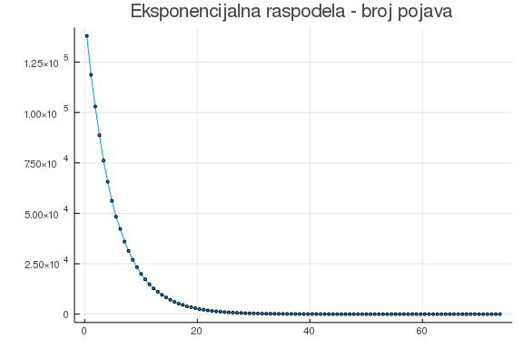

```julia
h, bins = hist(f, 100)
plot(bins, h, title="Eksponencijalna raspodela - broj pojava", marker=2, lab="")
```

Funkcija gustine verovatnoće eksponencijalne distribucije je:

```julia
exppdf(x, θ) = 1/θ * exp.(-x/θ);
```

i njen izgled je prikazan na donjem dijagramu.

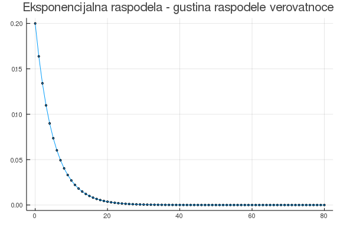

```julia
x = 0:1:80
plot(x, exppdf(x, θ), title="Eksponencijalna raspodela - gustina raspodele verovatnoce", marker=2, lab="")
```

### Normalna raspodela

Parametri Normalne raspodele su srednja vrednost μ i standardna devijacija σ.

Na sličan način kao prethodna raspodela i ovde će biti određeni srednja i maksimalna vrednost, a zatim će biti prikazani histogram generisanih vrednosti i izgled funkcije gustine verovatnoće normalne raspodele.

```julia
μ = 0.0         # srednja vrednost
σ = 1.0         # standardna devijacija
distribucija = Normal(μ, σ)
f = rand(distribucija, 10^6)
@show( mean(f), maximum(f) );
```

```
mean(f) = 0.00042473290199438623
maximum(f) = 4.656728981548758
```

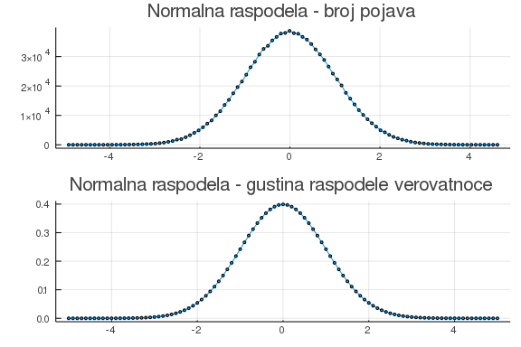

```julia
h, bins = hist(f, 100)
g1 = plot(bins, h, title="Normalna raspodela - broj pojava", marker=2, lab="")

x = -5:0.1:5
normpdf(X, μ, σ) = 1/σ/sqrt(2*π)*exp.(-(x .- μ).^2/(2*σ^2))         # f-ja gustine verovatnoće
g2 = plot(x, normpdf(x, μ, σ), title="Normalna raspodela - gustina raspodele verovatnoce", marker=2, lab="")

plot(g1, g2, layout=(2,1))
```

### Poasonova raspodela

Ovde se posmatra diskretna raspodela verovatnoće gde se izražava verovatnoća da se određeni broj događaja desi u datom intervalu vremena.

Parametar Poasonove raspodele je λ i jednak je očekivanoj vrednosti od *x*. Analiza Poasonove raspodele je urađena kao i kod prethodne raspodele.

```julia
λ = 5.0         # očekivan broj pojava
distribucija = Poisson(λ)
f = rand(distribucija, 10^6)
@show( mean(f), maximum(f) );
```

```
mean(f) = 5.000248
maximum(f) = 19
```

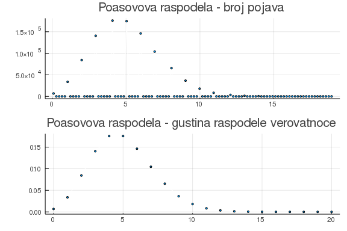

```julia
h, bins = hist(f, 100)
g1 = plot(bins, h, title="Poasovova raspodela - broj pojava", marker=2, lab="", lc=:white)

x = 0:1:20      # broj pojava
poisspdf(x, λ) = λ.^x .* exp(-λ) ./ factorial.(x)
g2 = plot(x, poisspdf(x, λ), title="Poasovova raspodela - gustina raspodele verovatnoce", marker=2, lab="", lc=:white)

plot(g1, g2, layout=(2,1))
```

## Primer

Posmatra se pošta sa jednim šalterom (servisom za opsluživanje klijenata) i jednim redom.

Vremena međudolazaka klijenata su opisana eksponencijalnom raspodelom sa prosečno 5 jedinica vremena između dva dolaska. Takođe, trajanje servisa se opisuje istom raspodelom sa prosečnim trajanjem od 2 jedinice vremena. Naredno programski kod simulira događanja tokom obrade 10 klijenta.

```julia
Random.seed!(0);

n = 10                          # broj klijenata

θd = 5.0                        # sr. vreme izmedju dolazaka
rd = rand(Exponential(θd), n)   # vremena izmedju dolazaka
d = cumsum(rd)                  # vremena dolazaka

θs = 2.0                        # sr. vreme između servisiranja
s = rand(Exponential(θs), n)    # vremena trajanja servisiranja

zi = d + s                      # idelano vreme zavrsetka servisiranja
z = d + s
for i = 2:n
    if d[i] < z[i-1]
        z[i] = z[i-1] + s[i]
    else
        z[i] = d[i] + s[i]
    end
end
c = z - zi;                     # vreme zadržavanja u redu
```

Donja tabela prikazuje vremena: dolaska, završetka servisiranja (nakon čekanja), teorijskog završetka da nije bilo čekanja i trajanja zadržavanja u redu.

```julia
using Printf
for i = 1:n
    @printf "%5.2f  %5.2f  (%5.2f)  %5.2f\n" d[i] z[i] zi[i] c[i]
end
```

```
3.91   6.23  ( 6.23)   0.00
 9.11  12.88  (12.88)   0.00
10.76  16.49  (14.37)   2.12
11.50  18.49  (13.50)   4.99
14.12  19.10  (14.73)   4.37
18.28  19.35  (18.53)   0.82
20.12  24.64  (24.64)   0.00
20.26  31.83  (27.46)   4.37
26.72  36.79  (31.68)   5.11
29.14  37.05  (29.39)   7.66
```

Na osnovu prethodno generisanih trenutaka uvode se dodatni podaci i nizovi kako bi se lakše odredili statistički pokazatelji zbivanja u pošti. Prvo se posmatraju dolasci i odlasci klijenata, gde se dolazak predstavi sa +1 jer za toliko povećava brojno stanje u pošti, a odlazak se označi sa -1. Kada se hronološki poređaju svi događaji dolazaka i odlazaka (tj. odgovarajuće vrednosti +1 i -1), tada se brojno stanje u pošti u trenucima tih događaja dobija kumulativnom sumom (niza sačinjenog od +/-1).

```julia
# priprema...
tdog    = [d; z]                        # svi događaji
dog     = [ones(n); -ones(n)]           # promena brojnog stanja sa događajem
iddog   = sortperm(tdog)                # indeksi sortiranog tdog
stdog   = tdog[iddog]                   # sortirana vremena događaja
sdog    = dog[iddog]                    # sortirani događaji (-1,+1)
brkl    = cumsum(sdog)                  # brojno stanje
brklred = (brkl .> 0) .* (brkl .- 1)    # broj klij. u redu (-1 zbog servisiranja)
tmax    = maximum(stdog);               # trajanje simulacije
```

Donji dijagrami pokazuju izračunato brojno stanje.

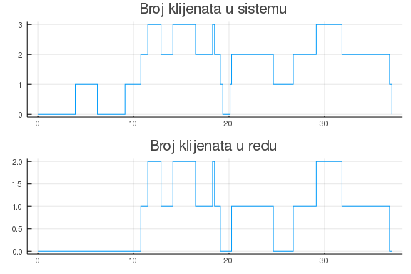

```julia
# dijagrami ...
g1 = plot([0; stdog], [0; brkl], title="Broj klijenata u sistemu", linetype=:steppost, lab="")
g2 = plot([0; stdog], [0; brklred], title="Broj klijenata u redu", linetype=:steppost, lab="")
plot(g1, g2, layout=(2,1))
```

Nadalje, neki statistički pokazatelji se mogu izračunati ...

```julia
txt = @sprintf "broj klijenata = %d\n" n

# prosečno vreme čekanja klijenta
pvc = mean(c)
txt *= @sprintf "prosečno vreme čekanja klijenta          = %.2f\n" pvc

# prosečno vreme zadržavanje u sistemu
pvz = mean(z - d)      # mean(s+c), tmax/n??
txt *= @sprintf "prosečno vreme zadržavanje u sistemu     = %.2f\n" pvz

# prosečan broj klijenata u redu čekanja (prosek dužine reda)
ss = diff(stdog)' * brklred[1:end-1]
pbr = ss / tmax
txt *= @sprintf "prosečan broj klijenata u redu čekanja   = %.2f\n" pbr

# prosečan broj klijenata u sistemu
ss = diff(stdog)' * brkl[1:end-1]
pbs = ss / tmax
txt *= @sprintf "prosečan broj klijenata u sistemu        = %.2f\n" pbs

# verovatnoća čekanja
vc = sum(c .> 0) / n
txt *= @sprintf "verovatnoća čekanja                      = %.2f\n" vc

# prosečno vreme (trajanje) servisiranja
pvs = mean(s)
txt *= @sprintf "prosečno vreme (trajanje) servisiranja   = %.2f\n" pvs

# verovatnoća slobodnog servisa
vss = (tmax - sum(s)) / tmax
txt *= @sprintf "verovatnoća slobodnog servisa            = %.2f\n" vss

# prosečno vreme između dolazaka
pvid = mean(diff(d))  # ili mean(rd)
txt *= @sprintf "prosečno vreme između dolazaka           = %.2f\n" pvid

# prosecno vreme čekanja (ako se čeka)
pvcac = mean(c[c .> 0])
txt *= @sprintf "prosecno vreme čekanja (ako se čeka)     = %.2f\n" pvcac

# iskorišćenost resursa
ir = sum(s) / tmax
txt *= @sprintf "iskorišćenost resursa                    = %.2f\n" ir

# verovatnoca da se u sistemu nalazi 0, 1, 2, 3, ... klijenata
txt *= @sprintf "verovatnoća da se u sistemu nalazi:\n"
for i = 0:10
    brklN = brkl .== i
    v = (diff(stdog)' * brklN[1:end-1]) / tmax
    global txt *= @sprintf "   %2d klijenata:  v = %5.4f\n" i v
end

println(txt)
```

[output not shown]

Kada se broj klijenata poveća na milion, za statističku obradu se dobiju sledeći rezultati:

```
broj klijenata = 1000000
prosečno vreme čekanja klijenta          = 1.34
prosečno vreme zadržavanje u sistemu     = 3.34
prosečan broj klijenata u redu čekanja   = 0.27
prosečan broj klijenata u sistemu        = 0.67
verovatnoća čekanja                      = 0.40
prosečno vreme (trajanje) servisiranja   = 2.00
verovatnoća slobodnog servisa            = 0.60
prosečno vreme između dolazaka           = 5.00
prosecno vreme čekanja (ako se čeka)     = 3.34
iskorišćenost resursa                    = 0.40
verovatnoća da se u sistemu nalazi:
    0 klijenata:  v = 0.5999
    1 klijenata:  v = 0.2400
    2 klijenata:  v = 0.0960
    3 klijenata:  v = 0.0386
    4 klijenata:  v = 0.0152
    5 klijenata:  v = 0.0062
    6 klijenata:  v = 0.0024
    7 klijenata:  v = 0.0010
    8 klijenata:  v = 0.0004
    9 klijenata:  v = 0.0002
   10 klijenata:  v = 0.0001
```

Published from Julija-SMO.jmd using Weave.jl on 2020-01-14.